# Bioinformatic Resources: project on lung-adenocarcinoma dataset

Rayan Slatni, Anastasia Santo, Alex Callegaro

2023-09-04

The aim of this project is to perform several analysis on cancer data, specifically on Lung Adenocarcinoma data, retrieved from 100 patients, including case and control groups.

**TASK 1:** load the RData file

```r
dim(c_anno_df)  #50 case and 50 controls
```

```
## [1] 100   2
```

```r
dim(r_anno_df)  #info gene 62940 genes
```

```
## [1] 62940     3
```

Among 100 samples we have information on 62940 expressed genes.

**TASK 2**: extract information only about protein coding. In order to do this we use the *hsapiens_gene_ensembl* dataset to retrieve the information needed to build a query.

```r
ensembl <- useEnsembl(biomart = "ensembl", dataset = "hsapiens_gene_ensembl", host = "useast.ensembl.org")
```

```r
query1 <- getBM(attributes = c("ensembl_gene_id", "entrezgene_id", "external_gene_name",
    "gene_biotype"), filters = c("ensembl_gene_id"), values = r_anno_df$ensembl_gene_id,
    mart = ensembl)

# extract only protein coding genes
query1_protein_coding <- query1[which(query1$gene_biotype == "protein_coding"), ]
```

Filter counts and annotation only for protein coding and remove the presence of possible duplicates.

```r
r_anno_df_pc <- r_anno_df[query1_protein_coding$ensembl_gene_id, ]
raw_counts_df_pc <- raw_counts_df[query1_protein_coding$ensembl_gene_id, ]

r_anno_df_pc <- r_anno_df_pc[-which(duplicated(r_anno_df_pc$ensembl_gene_id)), ]
raw_counts_df_pc <- raw_counts_df_pc[-which(duplicated(rownames(raw_counts_df_pc))),
    ]
dim(raw_counts_df_pc)
```

```
## [1] 22155   100
```

We ended up with 22155 genes coding for protein.

```r
count_thr <- 20  #threshold for raw count
repl_thr <- 5  #number of replicates

filter_vec <- apply(raw_counts_df_pc, 1, function(y) max(by(y, c_anno_df$condition,
    function(x) sum(x >= count_thr))))
# apply the filter on counts
filter_counts_df <- raw_counts_df_pc[filter_vec >= repl_thr, ]

# apply the filter on gene annotation
filter_anno_df <- r_anno_df_pc[rownames(filter_counts_df), ]
dim(filter_anno_df)
```

```
## [1] 17289     3
```

After the filtering we obtain 17289 genes.

The selected data have been then normalized using TMM (trimmed mean of M values) and then used to build a cpm (counts per million) table in order to have normalized expression values.

```r
edge_c <- DGEList(counts = filter_counts_df, group = c_anno_df$condition, samples = c_anno_df,
    genes = filter_anno_df)

edge_n <- calcNormFactors(edge_c, method = "TMM")
cpm_table <- as.data.frame(round(cpm(edge_n), 2))
```

At this point we can define the experimental design matrix and use it to calculate the dispersion maximizing the negative binomial likelihood and fit a genewise negative binomial generalized linear model with quasi-likelihood tests.

```r
design <- model.matrix(~0 + group, data = edge_n$samples)
colnames(design) <- levels(edge_n$samples$group)
rownames(design) <- edge_n$samples$sample
edge_d <- estimateDisp(edge_n, design)  #calculate dispersion
edge_f <- glmQLFit(edge_d, design)  #fit the model
```

Then we define the contrast according to the two conditions that we want to compare, and define the final model.

```r
contro <- makeContrasts("case-control", levels = design)
edge_t <- glmQLFTest(edge_f, contrast = contro)
```

For the final dataset we introduce some cut-off: select only genes with p-value 0.01, select logFC ratio grater than 1.5 for up-regulated genes and lower than -1.5 for down-regulated genes and select logCPM greater than 1.

```r
DEGs <- as.data.frame(topTags(edge_t, n = 20000, p.value = 0.01, sort.by = "logFC"))

DEGs$class <- "="
#+ - to see if the genes are up or down regulated
DEGs$class[which(DEGs$logCPM > 1 & DEGs$logFC > 1.5)] = "+"
DEGs$class[which(DEGs$logCPM > 1 & DEGs$logFC < (-1.5))] = "-"
DEGs <- DEGs[order(DEGs$logFC, decreasing = T), ]

table(DEGs$class)
```

```
##
##    -    +    =
##  884 1199 9258
```

As a result we obtaines 884 down-regulated genes and 1199 up-regulated genes. Now we display a volcano plot of the results:

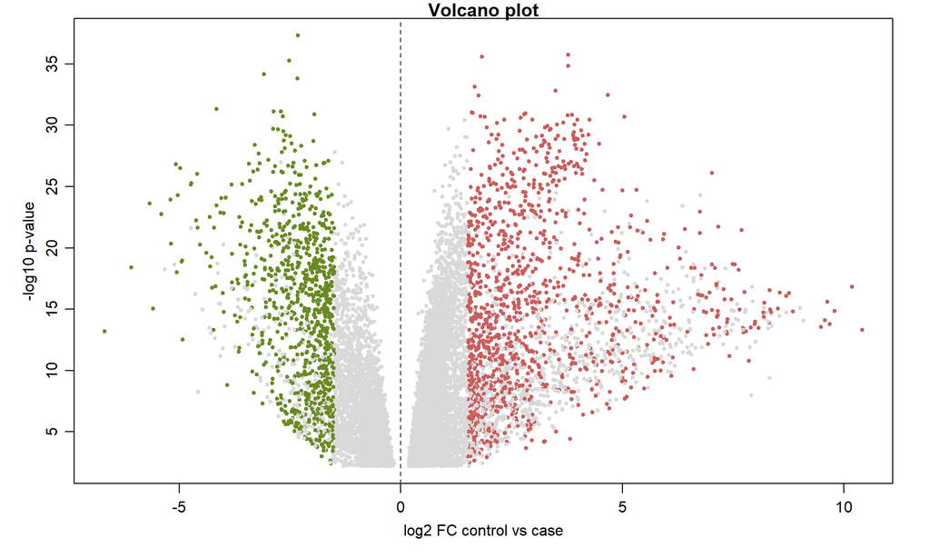

Volcano plot: red = up-regulated, green = down-regulated

From the volcano plot we can see that the up-regulated genes have a larger range of value for the log2 FC. We can use a heatmap to visualize the distinction between the two groups clustering with respect to up and down regulated genes. From the dendrogram we can see that the two groups are well clusterized according to the different gene expression.

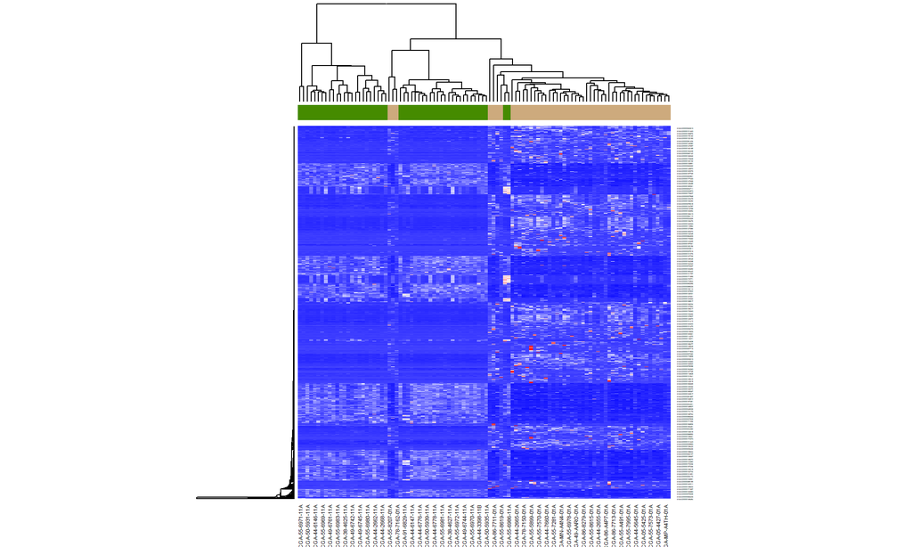

Heatmap with dendogram: green = control, yellow = case

**TASK 4**: Perform gene set enrichment analysis using clusterProfiler R package, performing both GO (BP and MF) and WP analysis.

First we add additional information to our genes from ensembl database.

```r
convert <- getBM(attributes = c("ensembl_gene_id", "entrezgene_id"), filters = c("ensembl_gene_id"),
    values = DEGs$ensembl_gene_id, mart = ensembl)

DEGs <- merge(DEGs, convert, by = "ensembl_gene_id")
```

Now we clean the data removing NA and duplicates and split in up and down regulated

```r
DEGs <- DEGs[which(!is.na(DEGs$entrezgene_id)), ]
DEGs <- DEGs[-which(duplicated(DEGs$entrezgene_id)), ]
up_DEGs <- DEGs[DEGs$class == "+", ]
down_DEGs <- DEGs[DEGs$class == "-", ]
```

Here we perform Enrichment analysis both for up and down regulated genes:

- **Ontology term: biological process**

```r
up_ego_BP <- enrichGO(gene = up_DEGs$external_gene_name, OrgDb = org.Hs.eg.db, keyType = "SYMBOL",
    ont = "BP", pAdjustMethod = "BH", pvalueCutoff = 0.05, qvalueCutoff = 0.05)

down_ego_BP <- enrichGO(gene = down_DEGs$external_gene_name, OrgDb = org.Hs.eg.db,
    keyType = "SYMBOL", ont = "BP", pAdjustMethod = "BH", pvalueCutoff = 0.05, qvalueCutoff = 0.05)
```

Visualize the top 10 enriched terms for the up regulated genes:

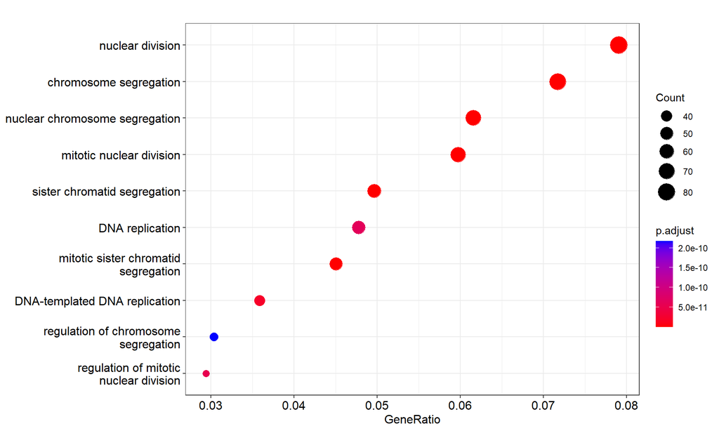

Dotplot for up-regulated genes (BP)

From the plot above we can see that most of the up-regulated genes are related to pathway connected to the cell cycle, in particular at the nuclear level, like the chromosome segregation and the DNA replication. Thanks to the heatplot we can highlight those genes related to the pathways above. Genes coding for Cell Division Cycle result upregulated for all the pathways.

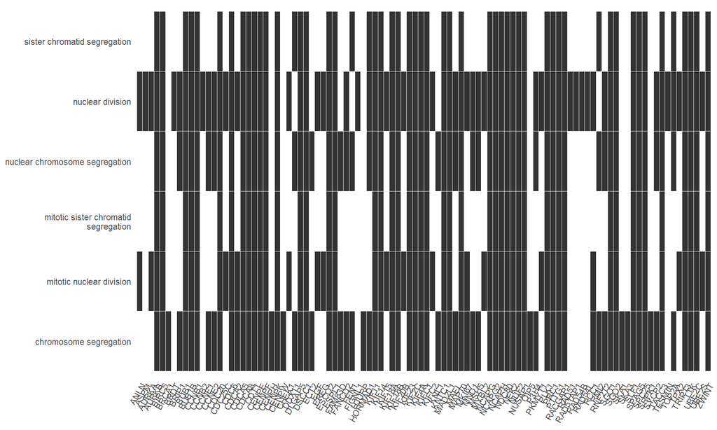

Heatplot for up-regulated genes (BP)

We can also plot an enrichment map that organizes enriched terms into a network with edges connecting overlapping gene sets. In this way, mutually overlapping gene sets tend tocluster together, making it easy to identify functional module.

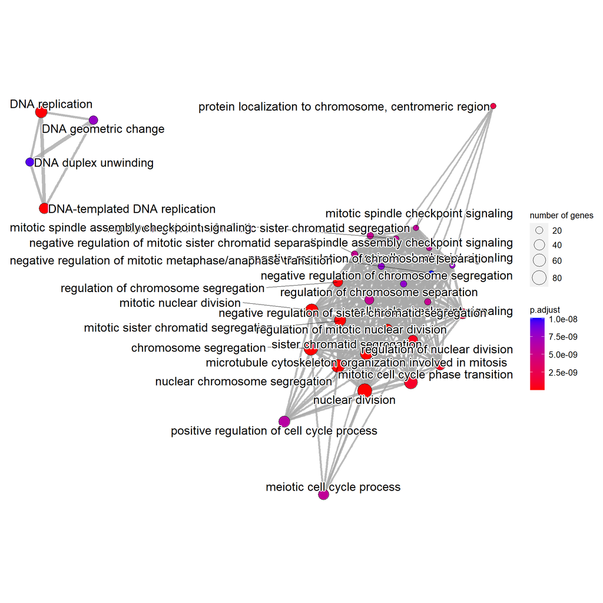

Emapplot for up-regulated genes (BP)

From this plot we can see a big cluster that include most of the biological process, including: cell cycle checkpoint signalling and chromosome segregation.

Here we visualize the top 10 enriched terms for the down-regulated genes

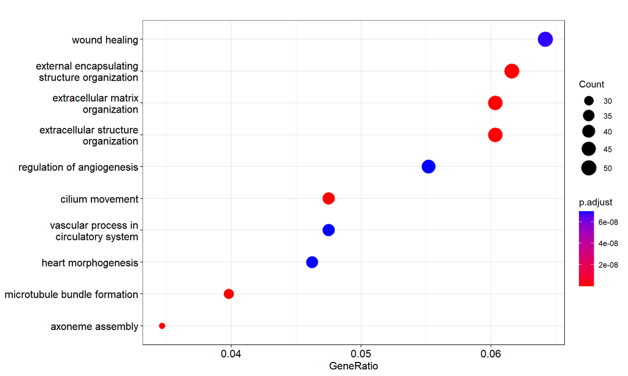

Dotplot for down-regulated genes (BP)

In the plot above we can see that most of the pathways are related to components of the cell structure, like extracellular matrix, cilium movement and microtubule formation.

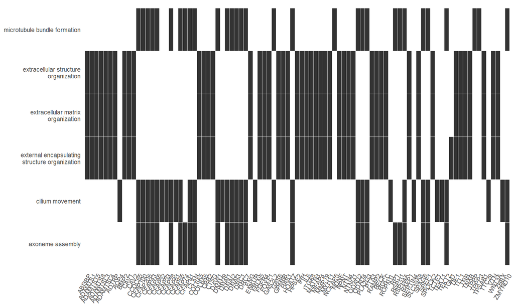

Heatplot for down-regulated genes (BP)

From the heatmap we can see that the genes belonging to the family ADAMTS (A Disintegrin-Like And Metalloprotease with Thrombospondin Motifs) are involved in the extracelullar organization.

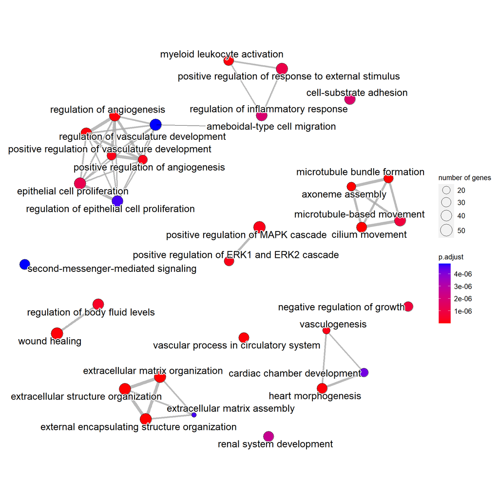

Emapplot for down-regulated genes (BP)

From the plot above we can see several small clusters. For example there is one cluster related to inflammatory response, and another one related to angiogenenis and control in vascularization.

- **Ontology term: molecular function**

```r
up_ego_MF <- enrichGO(gene = up_DEGs$external_gene_name, OrgDb = org.Hs.eg.db, keyType = "SYMBOL",
    ont = "MF", pAdjustMethod = "BH", pvalueCutoff = 0.05, qvalueCutoff = 0.05)

down_ego_MF <- enrichGO(gene = down_DEGs$external_gene_name, OrgDb = org.Hs.eg.db,
    keyType = "SYMBOL", ont = "MF", pAdjustMethod = "BH", pvalueCutoff = 0.05, qvalueCutoff = 0.05)
```

Visualize the top 10 enriched terms for the up regulated genes :

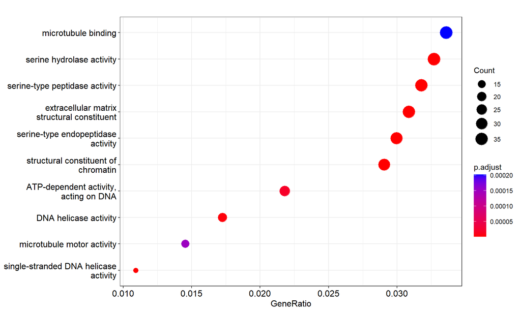

Dotplot for up-regulated genes (MF)

```
##  [1] "structural constituent of chromatin"
##  [2] "extracellular matrix structural constituent"
##  [3] "serine hydrolase activity"
##  [4] "single-stranded DNA helicase activity"
##  [5] "serine-type peptidase activity"
##  [6] "serine-type endopeptidase activity"
##  [7] "DNA helicase activity"
##  [8] "ATP-dependent activity, acting on DNA"
##  [9] "microtubule motor activity"
## [10] "microtubule binding"
```

From the plot above related to the molecular function for the up-regulated genes, we can see that most of the functions are related to enzimatic activity and structural constituent of chromatin.

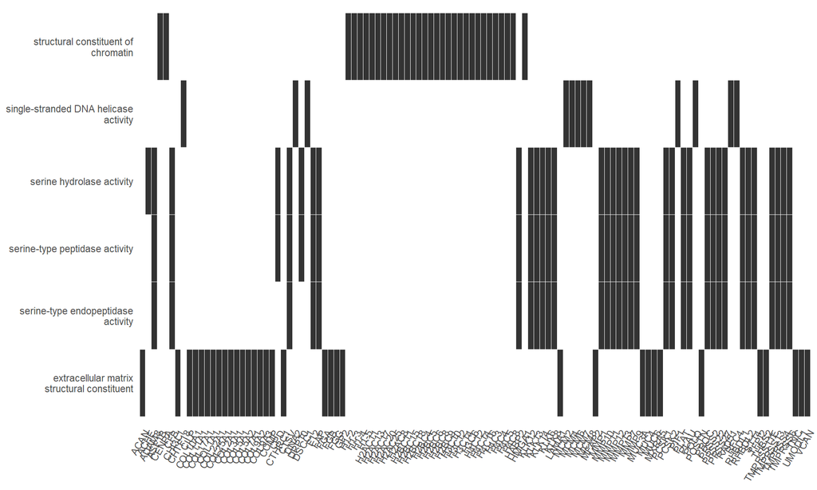

Heatplot for up-regulated genes (MF)

From the heatplot we can notice that many genes coding for histon protein (H2A, H2B, H4) are specific only for the structural constituent of chromatin.

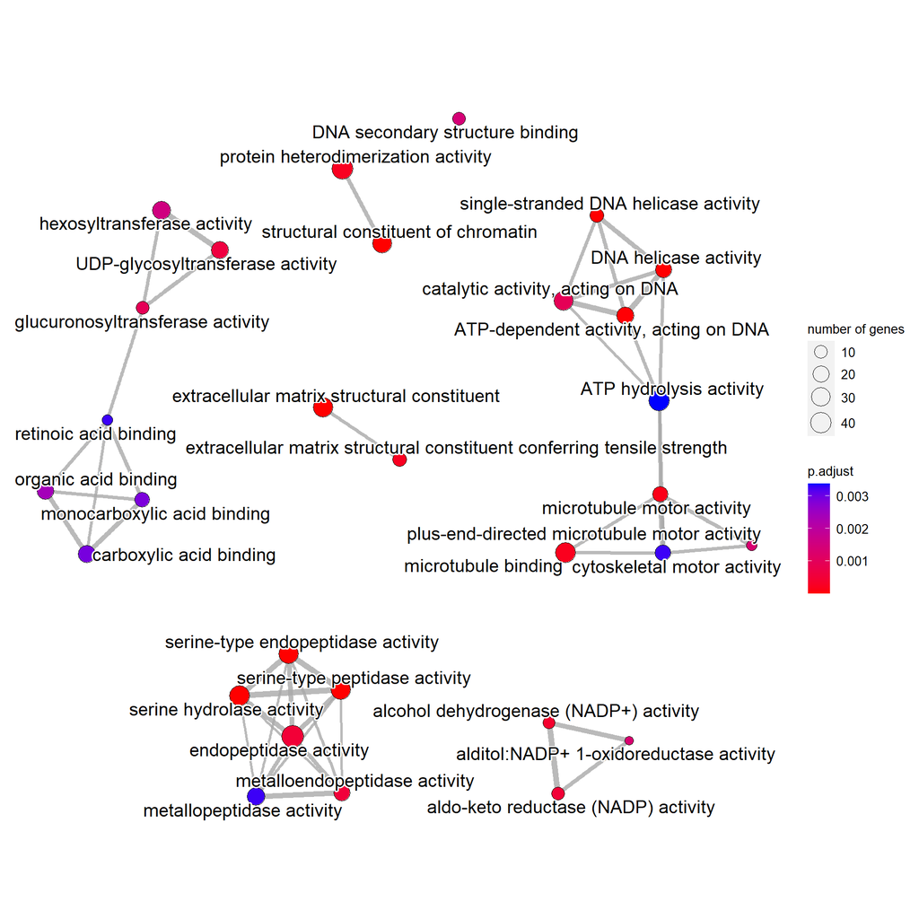

Emapplot for up-regulated genes (MF)

From this plot we can identify several networks for example there are links between the ATP hydrolysis activity, microtuble activity and ATP dependent activity acting on DNA.

Here we visualize the top 10 enriched terms for the down regulated genes:

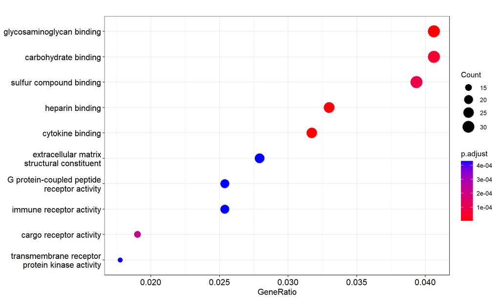

Dotplot for down-regulated genes (MF)

```
##  [1] "cytokine binding"
##  [2] "glycosaminoglycan binding"
##  [3] "heparin binding"
##  [4] "carbohydrate binding"
##  [5] "sulfur compound binding"
##  [6] "cargo receptor activity"
##  [7] "G protein-coupled peptide receptor activity"
##  [8] "extracellular matrix structural constituent"
##  [9] "immune receptor activity"
## [10] "transmembrane receptor protein kinase activity"
```

In the dotplot for the down regulated genes we can see that most of the functions are related to glycosaminoglycan, sulfur, heparin, cytokin and carbohydrate binding.

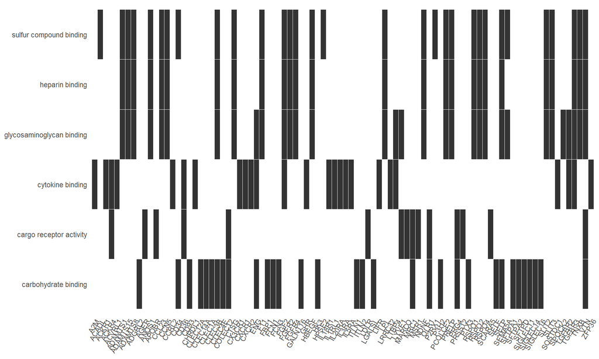

From the heatmap we can see that the genes belonging to the family ADAMTS, FGFR and RSPO are involved in the heparin, glycosaminoglycan and and sulfur compound binding.

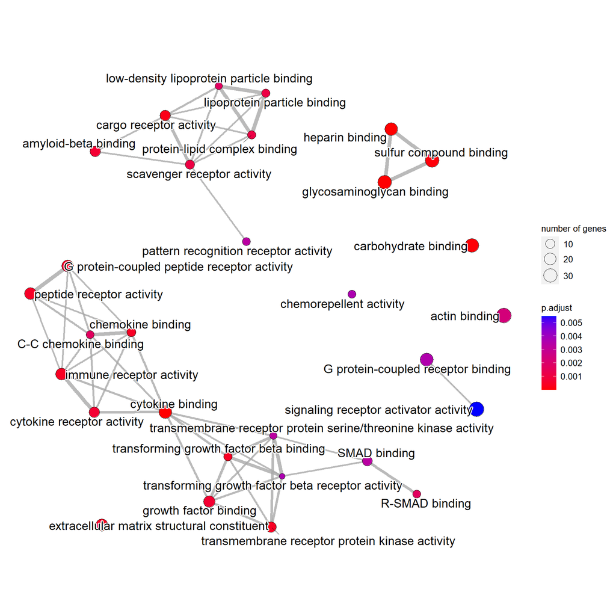

Emapplot for down-regulated genes (MF)

From this plot we can identify several networks for example there are links between the cargo receptor activity and lipoprotein particles binding, and between sulfur compound, glycosaminoglycan and heparin binding.

```r
up_eWP <- enrichWP(gene = up_DEGs$entrezgene_id, organism = "Homo sapiens", pvalueCutoff = 0.05,
    qvalueCutoff = 0.1)

down_eWP <- enrichWP(gene = down_DEGs$entrezgene_id, organism = "Homo sapiens", pvalueCutoff = 0.05,
    qvalueCutoff = 0.1)
```

Here we visualize the top 10 enriched terms for the down and up regulated genes:

```
##  [1] "Pancreatic cancer subtypes"
##  [2] "Retinoblastoma gene in cancer"
##  [3] "Gastric cancer network 1"
##  [4] "Cell cycle"
##  [5] "Codeine and morphine metabolism"
##  [6] "G1 to S cell cycle control"
##  [7] "DNA replication"
##  [8] "Regulation of sister chromatid separation at the metaphase-anaphase transition"
##  [9] "Glucuronidation"
## [10] "DNA IR-damage and cellular response via ATR"
```

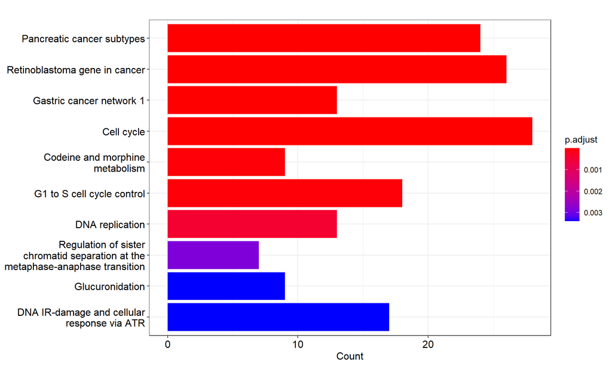

```
##  [1] "Complement system"
##  [2] "Complement activation"
##  [3] "10q22q23 copy number variation"
##  [4] "Complement and coagulation cascades"
##  [5] "Spinal cord injury"
##  [6] "Orexin receptor pathway"
##  [7] "Complement system in neuronal development and plasticity"
##  [8] "Familial hyperlipidemia type 2"
##  [9] "Adipogenesis"
## [10] "Cardiomyocyte signaling pathways converging on Titin"
```

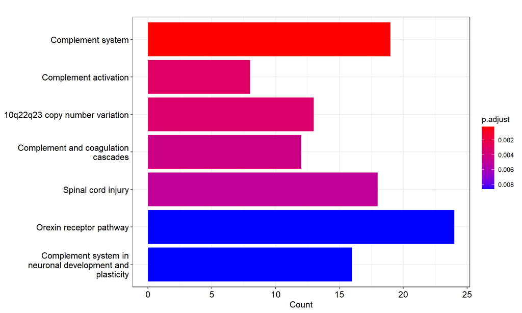

From the plot above we can see that most of the up-regulated genes are related to pathway connected to the cancer, like pancreatic cancer subtypes, cell cycle regulation. The down-regulated genes are related to pathway connected to complement system and coagulation cascades, 10q22q23 copy number variation and spinal cord injury.

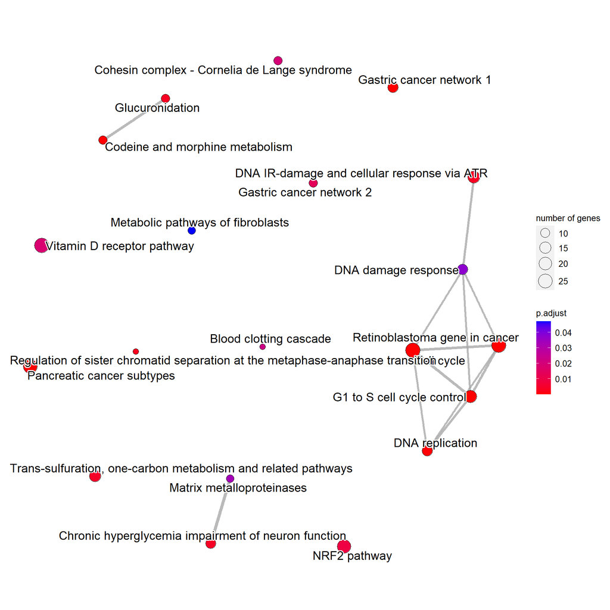

From this plot related to up-regulated genes we can identify some networks, for example there are links between the matrix metalloproteinases and the chronic hyperglycemia impairment of neuron function, and between the retinoblastoma gene in cancer and the DNA replication and control of the cell cycle.

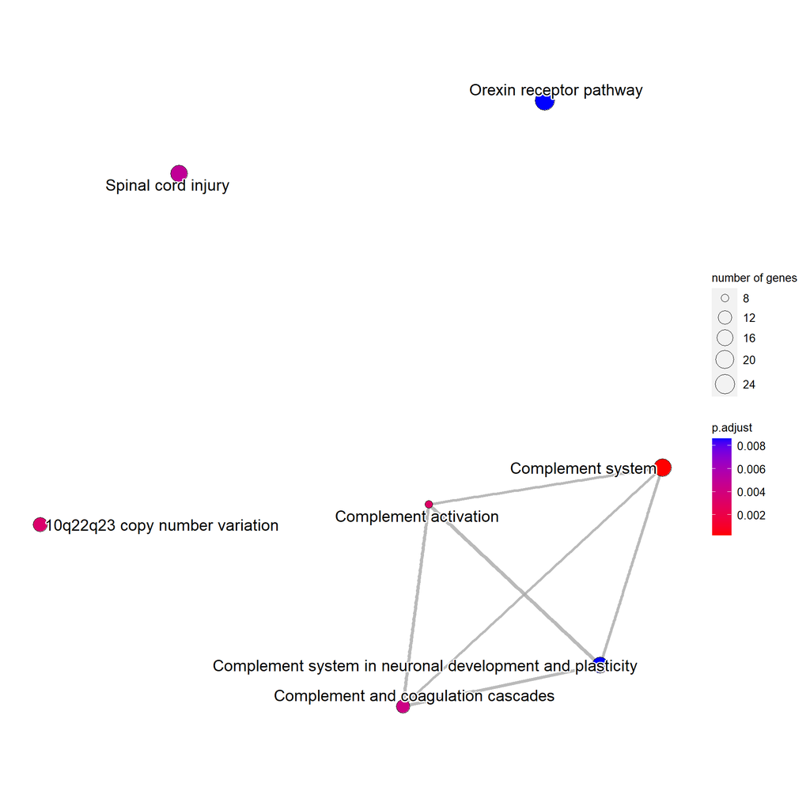

From this plot related to down-regulated genes we can identify one network, there are links between Complement system in neuronal development and plasticity,its activation, and coagulation cascades. While these genes are not correlated to the 10q22q23 gene copy number variation.

**TASK 5:** Here we use pathview R package to visualize one particular pathway enriched using the up-regulated gene list

We decided to plot the pathway “Gastric cancer network 1” which we found enriched in the previous analysis. We used the code *hsa05226* which is the code number representing this KEGG pathway.

```r
library(pathview)

logFC <- up_DEGs$logFC
names(logFC) <- up_DEGs$entrezgene_id

data(demo.paths)
pv.out <- pathview(gene.data = logFC, pathway.id = "hsa05226", species = "hsa", kegg.native = T)
head(pv.out$plot.data.gene)
```

```
##    kegg.names labels all.mapped type   x   y width height mol.data mol.col
## 8        3265   HRAS            gene 631 543    46     17       NA #FFFFFF
## 9         369   ARAF            gene 706 543    46     17       NA #FFFFFF
## 10       5604 MAP2K1            gene 781 543    46     17       NA #FFFFFF
## 11       5594  MAPK1            gene 857 542    46     16       NA #FFFFFF
## 15       6464   SHC1            gene 405 543    46     17       NA #FFFFFF
## 16       2885   GRB2            gene 481 543    46     17       NA #FFFFFF
```

The downstream analysis focuses only on down regulated genes (we made this choice for computational convenience since the down regulated ones are less).

**TASK 6:** In this step we identify the Transcription Factors which have enriched scores in the promoter of down regulated genes. The promoters are selected using the upstream sequence (window of 500nt) for the selected genes.

```r
promoter_seq <- getSequence(id = down_DEGs$ensembl_gene_id, type = "ensembl_gene_id",
    seqType = "gene_flank", upstream = 500, mart = ensembl)

sequences <- lapply(promoter_seq$gene_flank, function(x) DNAString(x))
length(sequences)
```

```
## [1] 874
```

We obtain 874 promoter sequences for the down regulated genes.

The motif enrichment has been calculated using the position weight matrix “PWMLogn.hg19.MotifDb.Hsap”. To save computational time the result of the function *motifEnrichment()* has been saved in *enriched_transcription.RData*.

```r
data(PWMLogn.hg19.MotifDb.Hsap)
# enriched_TFs <- motifEnrichment(sequences,PWMLogn.hg19.MotifDb.Hsap,score =
# 'affinity') save(enriched_TFs, file = 'enriched_transcription.RData')
load("C:/Users/rayan/OneDrive/Documenti/UNI/MAGISTRALE/Bioinformatics/Project/enriched_transcription.RData")
```

```r
report = groupReport(enriched_TFs)
```

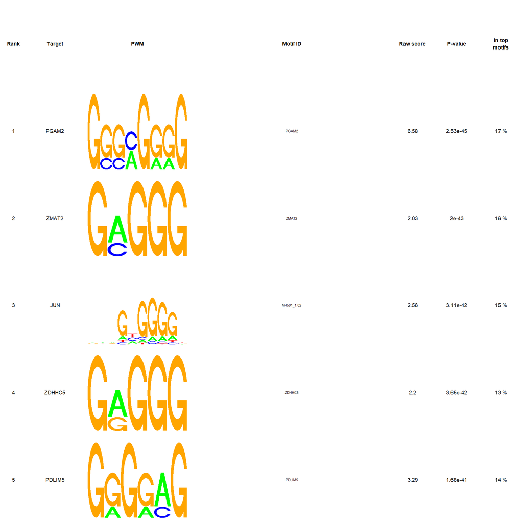

Plot of the PWMs for the first top 5 ranked target

**TASK 7:** Select one among the top enriched TFs, compute the empirical distributions of scores for all PWMs that you find in MotifDB for the selected TF and determine for all of them the distribution (log2) threshold cutoff at 99.75%.

```r
tfs = report$target[1]  #select top target
tfs
```

```
## [1] "PGAM2"
```

The target we will consider is PGAM2 (Phosphoglycerate Mutase 2)

```r
tfs_motifs = subset(MotifDb, organism == "Hsapiens" & geneSymbol == tfs)  #1 pos-fr-matrix
PWM = toPWM(as.list(tfs_motifs))  #position weight matrix for PGAM2
names(PWM) <- sapply(names(PWM), function(x) strsplit(x, "-")[[1]][3])
```

Here we calculate the empirical distributions of scores for the only one PWM found and we use a threshold-cutoff at 99.75%

```r
ecdf = motifEcdf(PWM, organism = "hg19", quick = TRUE)
threshold = log2(quantile(ecdf$PGAM2, 0.9975))  #compute the threshold
```

Here we use the *motifScores()* function to obtain the raw scores at each position in the sequences.

```r
scores = motifScores(sequences, PWM, raw.score = TRUE, cutoff = unlist(threshold))
```

Use the *plotMotifScores()* function to plot the log2 scores over the first 5 sequence. The motif hits are shown as rectangles with the base being the length of the motif, and the height being the log2 score of the motif hit. The forward strand hits are shown on the top, and the reverse strand hits are shown on the bottom.

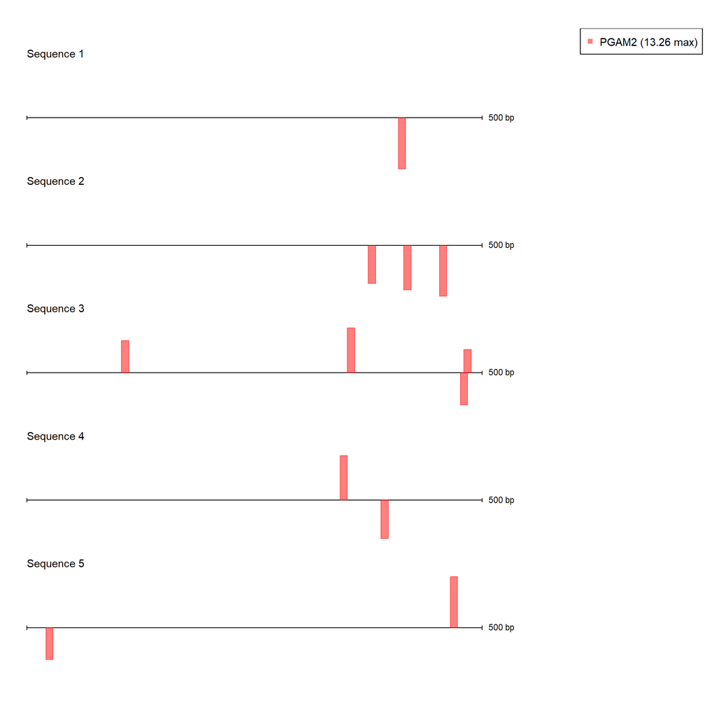

Plot of motif scores of the first 5 sequences for the motif PGAM2

**TASK 8:** Starting from the list of the TFs we got before, we want to identify which of the down-regulated genes have a binding site in their upstream sequence for the TFs. We will only consider sites with a threshold above of the one calculated above. We will use Pattern Matching.

Select which down-reg genes have a region in their promoter with binding scores above the threshold for any of the selected PWMs. We upload the results in two files.

```r
# TFs <- report$target fractions_99_9<-c() scoress <-
# data.frame(c(1:length(sequences))) for (i in (1:length(TFs))){ TFs_motif <-
# subset(MotifDb, organism == 'Hsapiens' & geneSymbol == TFs[i]) PWMs <-
# toPWM(as.list(TFs_motif)) names(PWMs) <- sapply(names(PWMs),function(x)
# strsplit(x,'-')[[1]][3]) ecdfs <- motifEcdf(PWMs, organism = 'hg19', quick =
# T) threshold <-lapply(ecdfs,function(x) log2(quantile(x,0.9975))) name <-
# TFs[i] score <- motifScores(sequences, PWMs, raw.scores = FALSE, cutoff =
# unlist(threshold)) fractions_99_9 =
# c(fractions_99_9,length(which(apply(score,1,sum)>0))/874) #how many sequences
# for each TFs have a total score higher than zero sco <-
# as.data.frame(apply(score, 1, sum)) #I compute the total score for each
# sequence colnames(sco) <- name length(sequences) scoress<- cbind(scoress,
# sco) }

# save(scoress, file = 'Scorestable.RData') #874 rows ( sequences) and target
# TFs columns save(fractions_99_9, file = 'fractions.RData')
load("C:/Users/rayan/OneDrive/Documenti/UNI/MAGISTRALE/Bioinformatics/Project/Scorestable.RData")
load("C:/Users/rayan/OneDrive/Documenti/UNI/MAGISTRALE/Bioinformatics/Project/fractions.RData")
```

In the file *Scorestable.RData* we saved the score of each TFs for each upstream sequence of the genes. At this point we filter the TFs based on these criteria : 1) if a TF has null scores for all the sequences we won’t consider it, same for sequences which have 0 values for every TFs; 2) we will keep only the sequences which have the greatest number of TFs binding region with a score higher than the median value of the score distribution.

Since the first column contains the length of each sequence we will remove it

```r
scoress <- as.matrix(scoress[, 2:length(scoress)])
head(scoress[, 1:8])
```

```
##      PGAM2 ZMAT2 JUN ZDHHC5 PDLIM5 GPD1 MAFK JUNB
## [1,]     5     4  19      3      6    5   33   21
## [2,]     3     6  36      7      9    4   59   25
## [3,]     1     3  47      3      2    1   52   34
## [4,]     3     5  23      2      2    3   19    8
## [5,]     3     6  10      4      2    2    2    2
## [6,]     2     5  29      4      3    4   31   32
```

```r
dim(scoress)  #524 TFs
```

```
## [1] 874 524
```

The matrix contain the scores computed between 524 TFs and 874 sequences.

```r
# filter out TFs that don't have any score greater than 0 for any of the
# sequences
for (i in (1:length(fractions_99_9))) {
    if (fractions_99_9[i] <= 0/874) {
        col <- i
        scoress <- scoress[, -col]
    }
}

dim(scoress)  #874 524
```

```
## [1] 874 524
```

```r
for (i in (1:length(sequences))) {
    if (sum(scoress[i, ]) < 0) {
        scoress <- scoress[-i, ]
    }
}
dim(scoress)
```

```
## [1] 874 524
```

After removing the zero columns we can see that no-TFs have a 0 score for every of the 874 sequences, same for sequences. Here we analyze the empirical distribution of each TFs, and we will use the median as a threshold in order to choose which down-regulated genes have a region in their promoter for a specific TFs.

Our threshold will be the median of each distribution

```r
thresholds <- c()

for (i in (1:ncol(scoress))) {
    thresholds <- c(thresholds, median(scoress[, i]))
}
```

Here I have a vector with the median of each distribution of each TFs scores. I will consider that an upstream-sequence have a region binding a TFs if its score is over the median for its distribution

```r
for (i in (1:ncol(scoress))) {
    for (u in (1:nrow(scoress))) {
        if (scoress[u, i] < thresholds[i]) {
            scoress[u, i] <- 0
        }
    }
}
countTFsperseq <- c()

for (i in (1:nrow(scoress))) {
    countTFsperseq <- c(countTFsperseq, length(which(scoress[i, ] != 0)))
}
```

This vector contains, for each upstream sequence of the down-regulated genes, how many TF-binding regions are present. Specifically, for the TFs we had choosen as a target before, we can see how many sequences does it bind :

```r
length(which(scoress[, "PGAM2"] != 0))
```

```
## [1] 479
```

It binds 479 upstream-sequences

We want to select only the sequences that binds a large number of TFs. For this filtering we select the sequence above the median level.

```r
median(countTFsperseq)
```

```
## [1] 290
```

```r
x <- which(countTFsperseq > 290)
top_enrich <- promoter_seq$ensembl_gene_id[x]
down_names <- down_DEGs$external_gene_name[which(top_enrich %in% down_DEGs$ensembl_gene_id)]
# write.table(down_names,file='down_names.txt',row.names=F,col.names=T,sep='\t',quote=F)
```

After this filtering we obtain 436 promoter sequence for the down-regulated genes which are statistically relevant.

**TASK 9:** Use STRING database to find protein-protein interactions among differentially expressed genes. Upload the list *down_names.txt* on the online database STRING in order to find the PPI (the results are in the file *string_interactions_short.tsv*.

```r
links <- read.delim("C:/Users/rayan/OneDrive/Documenti/UNI/MAGISTRALE/Bioinformatics/Project/string_interactions_short.tsv")
```

**TASK 10:** Import the network in R and using igraph package and identify and plot the largest connected component.

First retrieve the annotations for building the nodes using biomaRt

```r
ensembl <- useMart(biomart = "ensembl", dataset = "hsapiens_gene_ensembl")

nodes <- getBM(attributes = c("external_gene_name", "ensembl_gene_id", "description",
    "gene_biotype", "start_position", "end_position", "chromosome_name", "strand"),
    filters = c("ensembl_gene_id"), values = top_enrich, mart = ensembl)
```

Select the edges corresponding to the genes present in the nodes.

```r
nodes <- unique(nodes[, c(1, 3:6)]) %>%
    arrange(external_gene_name)
index <- links$node2 %in% nodes$external_gene_name
links <- links[index, ]
index <- links$X.node1 %in% nodes$external_gene_name
links <- links[index, ]
```

Create the network and simplify it removing multiple edges.

```r
net <- graph_from_data_frame(d = links, vertices = nodes, directed = FALSE)
net <- simplify(net)
```

```r
length(E(net))
```

```
## [1] 360
```

```r
length(V(net))
```

```
## [1] 436
```

Our network contains 436 nodes and 360 edges.

Identify and plot the largest connected component

```
## [1] 131
```

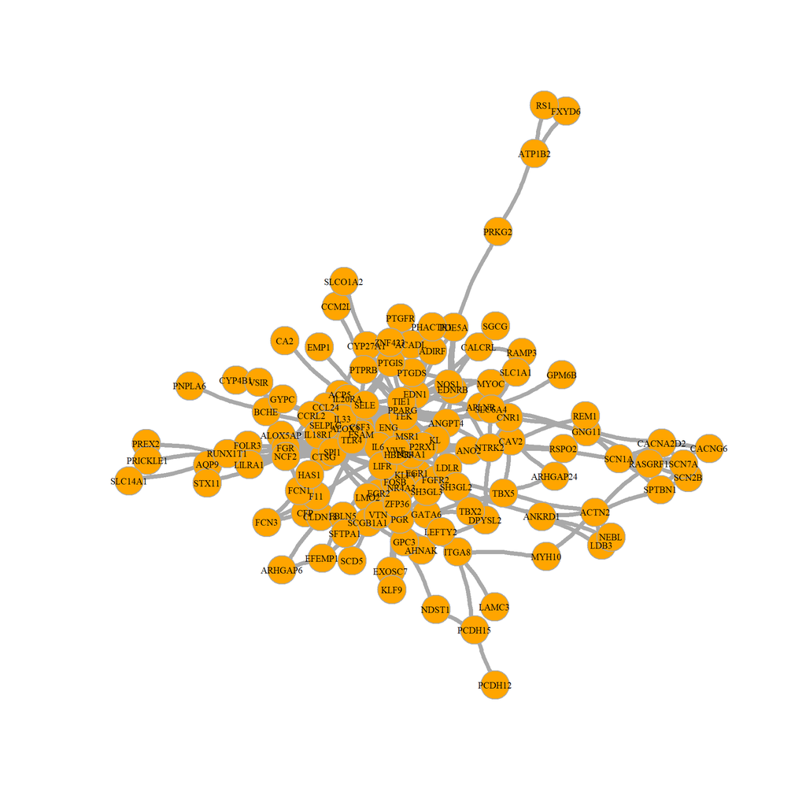

Network plot

Using edges as a reference we build the clusters.

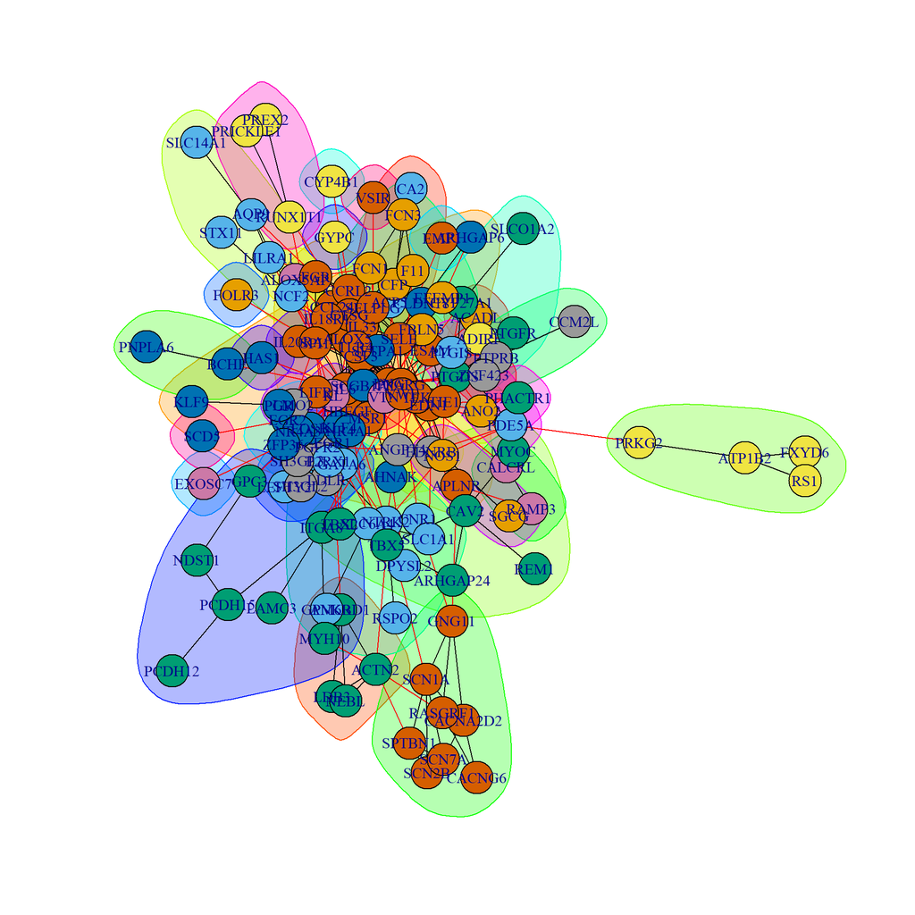

Network plot highlighting the clusters

We used the results of the first three cluster to look for similarity with the GO pathways highlighted before using the online tool STRING.

Cluster 1 present protein related the molecular function of: transmembrane receptor protein tyrosine kinase activity (same result in GO:MF) and adrenomedullin receptor activity (GO:MF immune receptor activity). Cluster 2 preset terms related to the biological process cardiac myofibril assembly (GO:BP heart morphology). For KEGG pathway the genes founded are related to morphine addiction (KEGG pathway: codeine and morphine metabolism). Cluster 3 found for biological process: positive regulation of plasma membrane repair, membrane raft assembly (terms connected to the extracellular matrix organization) and respiratory gaseous exchange by respiratory system that can be associated to GO:BP vascular process in circulatory system.

Collecting these results we can say that the pathways related to immune system, vascular system and heart functionality play an important role in the development of lung adenocarcinoma carcer.